# EU regional models

# Other - simple random models, just for the sake of doing it

Here are the results of the per capita, per researchers, and raw count simple linear models.

```r
percapita_lm <- lm (count_per_million ~ gdp_pps +
                      researcher_employment_pct +
                      disposable_income +
                      edu_attainment_total +
                      internet_use_banking_pc,
                    data = eurostat_complete_data)

perresearcher_lm <- lm (count_per_thousand_researchers ~
                          gdp_pps  + disposable_income +
                          edu_attainment_total +
                          internet_use_banking_pc,
                        data = eurostat_complete_data)
count_lm <- lm (count ~ gdp_pps +
                    researcher_employment_pct +
                    disposable_income +
                    edu_attainment_total +
                    internet_use_banking_pc +
                    gerd+internet_purchases_last_year_pc,
                data = eurostat_complete_data)
vif(count_lm)
```

```
##                         gdp_pps       researcher_employment_pct
##                        1.235016                        3.182476
##               disposable_income            edu_attainment_total
##                        2.381141                        2.502546
##         internet_use_banking_pc                            gerd
##                        3.318307                        2.439704
## internet_purchases_last_year_pc
##                        4.715426
```

```r
export_summs(percapita_lm,perresearcher_lm,count_lm,
             digits=10, statistics = "all",
             model.names=c('percapita', 'perresearcher','count')
             )
```

|  | percapita | perresearcher | count |
| --- | --- | --- | --- |
| (Intercept) | -12763.7378913799 *** | 3710.7625502644 *** | -8173.4161105523 |
|  | (3523.2692575711) | (599.9872808217) | (5286.4424339746) |
| gdp_pps | -0.0175480164 | -0.0014413293 | 0.2927763212 *** |
|  | (0.0162491675) | (0.0028579102) | (0.0232935271) |
| researcher_employment_pct | 15885.7284859612 *** |  | 28759.5332345133 *** |
|  | (1945.7957061601) |  | (3705.9297218099) |
| disposable_income | 1.5368260722 *** | 0.0307481696 | 1.2072023159 ** |
|  | (0.2577285755) | (0.0452299255) | (0.4183263035) |
| edu_attainment_total | 103.3661973273 | 12.0436603325 | 23.5737220600 |
|  | (126.9985173642) | (20.4993615895) | (197.9742668428) |
| internet_use_banking_pc | -328.6762527926 *** | -47.9116783495 *** | -340.9812430210 *** |
|  | (50.4213514487) | (9.0531345735) | (96.1465056351) |
| gerd |  |  | -8393.4118210641 *** |
|  |  |  | (1483.7250026908) |
| internet_purchases_last_year_pc |  |  | 13.1539199812 |
|  |  |  | (111.8683700805) |
| nobs | 265 | 265 | 265 |
| r.squared | 0.4311475504 | 0.1360504936 | 0.6201146782 |
| adj.r.squared | 0.4201658429 | 0.1227589627 | 0.6097676072 |
| sigma | 13526.0906886901 | 2429.8313802648 | 19336.0135043475 |
| statistic | 39.2605202459 | 10.2358783885 | 59.9314218449 |
| p.value | 0.0000000000 | 0.0000001035 | 0.0000000000 |
| df | 6.0000000000 | 5.0000000000 | 8.0000000000 |
| logLik | -2893.7637993945 | -2439.3227683843 | -2987.4341151134 |
| AIC | 5801.5275987890 | 4890.6455367686 | 5992.8682302267 |
| BIC | 5826.5857075710 | 4912.1239157245 | 6025.0857986606 |
| deviance | 47385378493.5353012085 | 1535060939.4951200485 | 96087524487.7590026855 |
| df.residual | 259.0000000000 | 260.0000000000 | 257.0000000000 |
| *** p < 0.001; ** p < 0.01; * p < 0.05. |  |  |  |

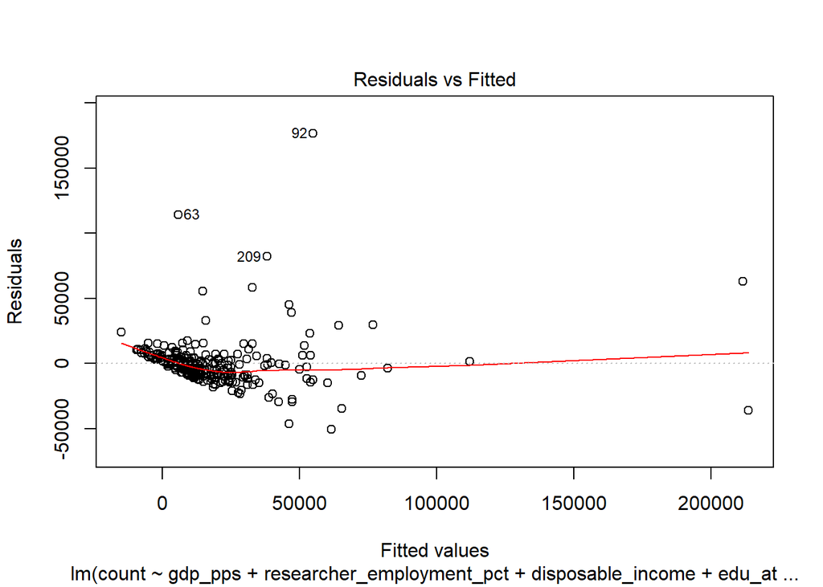

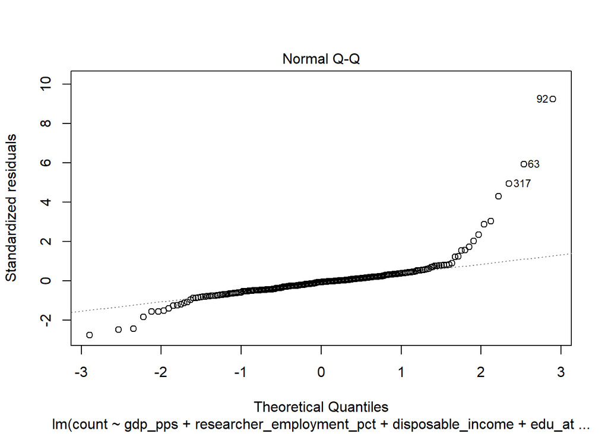

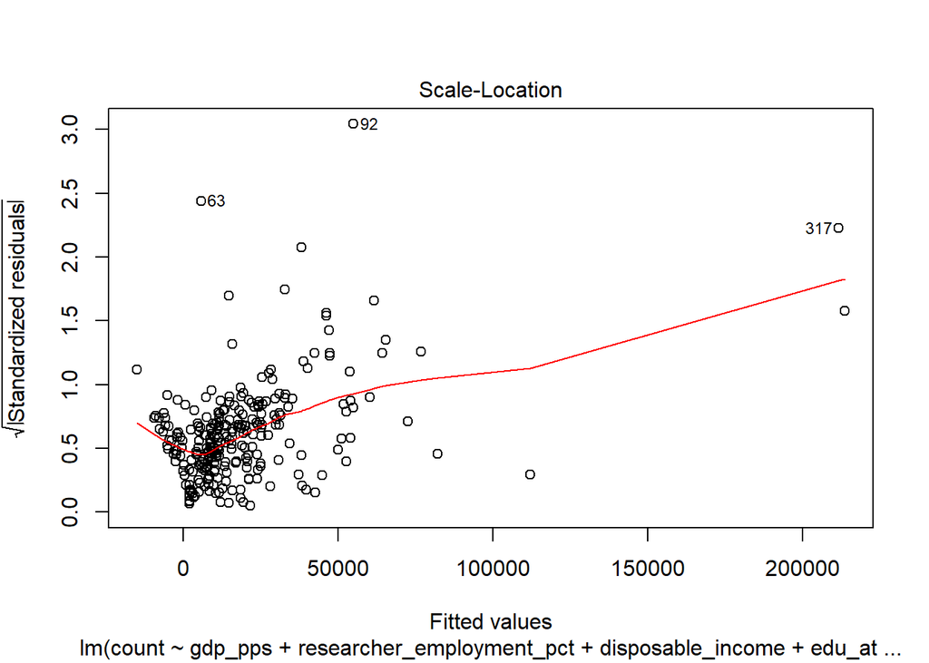

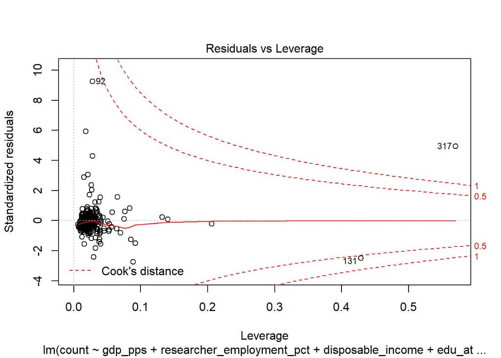

```r
plot(count_lm)
```

The standard linear model for the count variable shows the same as the Poisson and quasipoisson models:

- downloads grow with wealth, researcher share, and disposable income, but are moderated by online proficiency and R&D investment.
- online purchases are not significant, neither is the level of education. the model fit is comparable to the quasipoisson model fits.

we also have to note that linear models behave extremely bad in high count regions, worse than quasipoisson models.

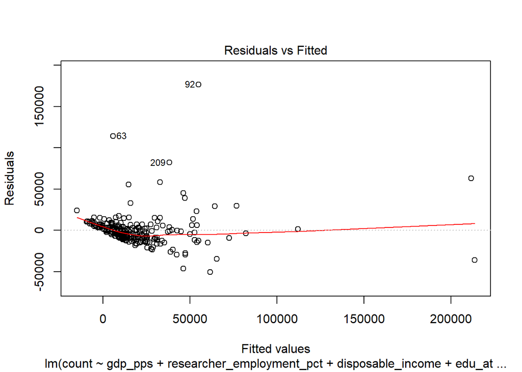

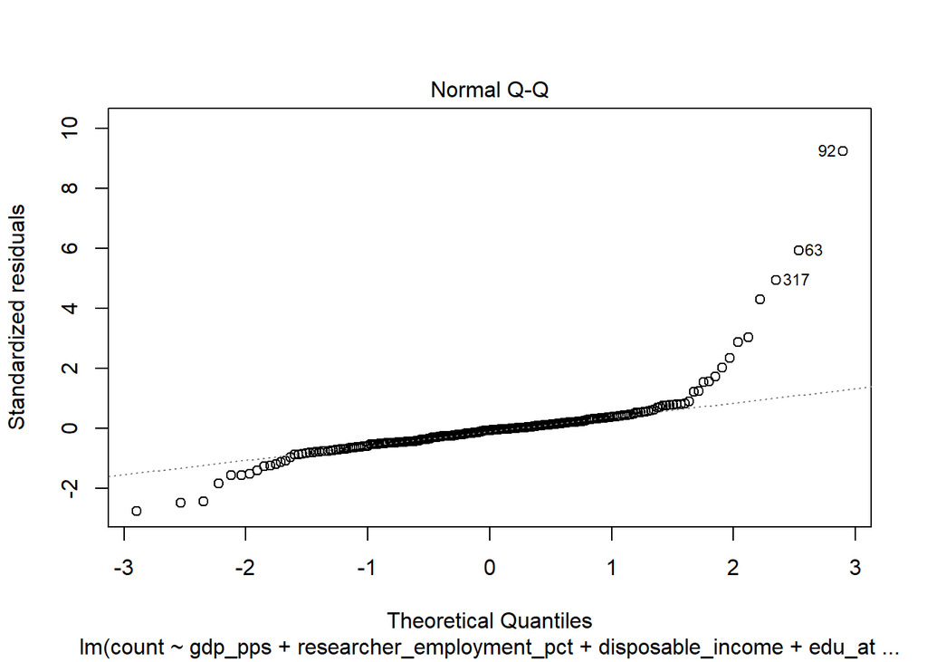

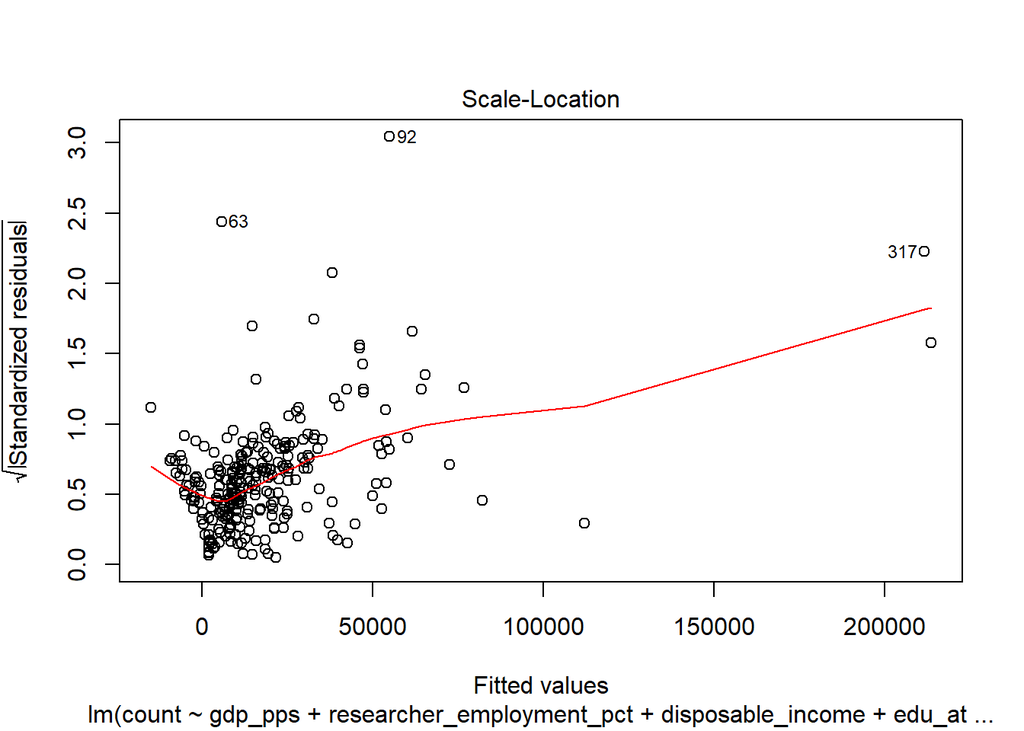

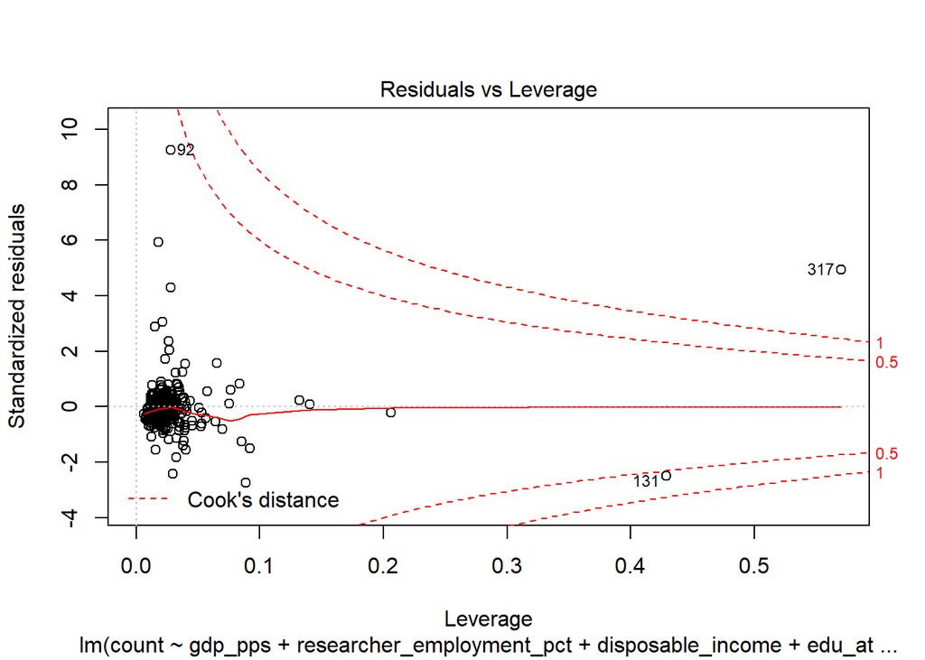

```r
plot(count_lm)
```